# Pr1_32

This project aims at performing a topic modeling analysis by using the datasets provided.

The `dataset` folder contains the datasets.

The `paper` folder contains the paper of the assignment.

The `figures` folder contains the figures generated by the analysis.

The `results` folder contains datasets generated by the analysis.

The `scripts` folder contains the notebooks used in the analysis.

The `presentation` folder contains the files used to generate the presentation.

## Extract the reference list from the given paper PDF, and look for the referenced papers as well as their metadata on PubMed

### Extract text from the paper's pdf and build a references list accordingly

```python
import os
import pandas as pd
import re
from pypdf import PdfReader

# Function to extract references from a PDF file using a context-aware pattern
def parse_references(pdf_path):
    reader = PdfReader(pdf_path)
    refs = []
    ref_section = False # Use as a flag to find the references section
    last_ref_num = 0 # To track the last reference number

    for page in reader.pages:
        # Extract text on a page by page basis
        text = page.extract_text()
        # When the "References" bit is found, cut out the text preceding it
        if "References" in text:
            ref_section = True
            text = text.split("References", 1)[1]
        if ref_section:
            # Find all matches of reference pattern
            for match in re.finditer(r'(\d+)\. (.*?\..*?)\.', text, re.DOTALL):
                current_ref_num = int(match.group(1))
                # Append reference if the current reference number is sequential
                if current_ref_num == last_ref_num + 1:
                    refs.append(match.group(2))
                    last_ref_num = current_ref_num
    # Use dot as column separator for Author and Title (as in the PDF)
    references = pd.DataFrame(refs)[0].str.split('.', n=1, expand=True)
    references.columns = ['Author', 'Title']
    # Replace newline characters with space and strip leading whitespace
    return references.applymap(lambda x: x.replace('\n', ' ').strip())

pdf = os.path.join('..','paper','s40798-019-0202-3.pdf')

# Extract references using the context-aware pattern from the uploaded PDF file
references_full = parse_references(pdf)

references_full.to_csv(os.path.join('..','results','paper_refs.csv'), index=False)

references_full.head()
```

|  | Author | Title |
| --- | --- | --- |
| 0 | Russell S, Norvig P | Artificial Intelligence: a modern approach |
| 1 | Witten IH, Frank E, Hall MA, et al | Data Mining: practical Machine Learning tools ... |
| 2 | Zaki MJ, Meira Jr, W | Data Mining and analysis: fundamental concepts... |
| 3 | Passfield L, Hopker JG | A mine of information: can sports analytics pr... |
| 4 | Rein R, Memmert D | Big data and tactical analysis in elite soccer... |

#### Only include the studies that were relevant to the systematic review (i.e., exclude papers that were used as methodology references)

```python
# According to the paper, 58 studies in total were included in the systematic review [15, 20–76]

# Save only the studies that are relevant to the systematic review
references = references_full.iloc[[14] + list(range(19, 76))]

references.to_csv(os.path.join('..','results','refs_systematic.csv'), index=False)

references.head()
```

|  | Author | Title |
| --- | --- | --- |
| 14 | López-Valenciano A, Ayala F, Puerta JM, et al | A preventive model for muscle injuries: a nove... |
| 19 | Li C | Predict the neural network mathematical model ... |
| 20 | Lu G | Evaluation model of young basketball players ’... |
| 21 | Wu L | The participating team ’s technical analysis o... |
| 22 | Zhang Q | Prediction based on basketball competition vid... |

### Scrape PubMed's database in order to find study IDs corresponding to our references

```python
# https://medium.com/@felipe.odorcyk/scrapping-data-from-pubmed-database-78a9b53de8ca

from Bio import Entrez

def search_pubmed(query, email):
    # The Pubmed API requires an email to be used
    Entrez.email = email
    # Set how the search should be performed
    handle = Entrez.esearch(db='pubmed',sort='relevance',
    retmax='1',
    retmode='xml',
    term=query)
    results = Entrez.read(handle)
    return results

mazza = 'matteo.mazzarelli@gmail.com'

studyids = []
for index, row in references.iterrows():
    # Splitting the author field and taking the first author only
    author = row['Author'].split(',')[0].strip()
    # Splitting the title field and taking the first five words
    title = ' '.join(row['Title'].split()[:5])

    # Forming the query and searching
    studies = search_pubmed(f"{author} {title}", mazza)
    # Get the first PubMed ID from the results, if any
    pubmed_id = studies['IdList'][:1]
    if pubmed_id:
        # Append a tuple of (index, PubMed ID)
        studyids.append((index, pubmed_id[0]))

studyids[:5]
```

```
[(14, '29283933'),
 (19, '37182376'),
 (23, '24993662'),
 (35, '28692649'),
 (37, '24034723')]
```

#### Using the study IDs we found, fetch the information we are looking for from PubMed's DB (in particular, abstracts)

```python
def fetch_details(id_tuples, email):
    # Flatten the list of lists into a single list
    id_list = [pubmed_id for _, pubmed_id in id_tuples]
    # Join the IDs with commas
    ids = ','.join(id_list)
    # The Pubmed API requires an email to be used
    Entrez.email = email
    handle = Entrez.efetch(db='pubmed', retmode='xml', id=ids)
    results = Entrez.read(handle)
    return results

# Create a dictionary to quickly find the index by PubMed ID
index_dict = {pubmed_id: index for index, pubmed_id in studyids}

index_list = []
author_list = []
title_list = []
abstract_list = []
journal_list = []
year_list = []

papers = fetch_details(studyids, mazza)

for i, paper in enumerate(papers['PubmedArticle']):
    pubmed_id = paper['MedlineCitation']['PMID']
    index = index_dict.get(pubmed_id, 'No Index') # Get the index from the dictionary
    index_list.append(index)
    authors = paper['MedlineCitation']['Article']['AuthorList']
    author_names = []
    for author in authors:
        # Some authors might not have a LastName or Initial, handle these cases
        last_name = author.get('LastName', '')
        initials = author.get('Initials', '')
        author_names.append(f"{last_name} {initials}".strip())

    # Join all authors' names with commas
    all_authors = ', '.join(author_names)
    author_list.append(all_authors)

    title_list.append(paper['MedlineCitation']['Article']['ArticleTitle'])

    # Fetch abstract, journal & publication year. If not found, set NA
    try:
        abstract_list.append(paper['MedlineCitation']['Article']['Abstract']['AbstractText'][0])
    except:
        abstract_list.append('')
    try:
        journal_list.append(paper['MedlineCitation']['Article']['Journal']['Title'])
    except:
        journal_list.append('')
    try:
        year_list.append(
            paper['MedlineCitation']['Article']['Journal']['JournalIssue']['PubDate']['Year'])
    except:
        year_list.append('')

# Create a pandas df with the results
abstracts = pd.DataFrame(list(zip(
    index_list, abstract_list, journal_list, year_list
)),
columns=['Ref #', 'Abstract', 'Journal', 'Year'])

abstracts.head()
```

|  | Ref # | Abstract | Journal | Year |
| --- | --- | --- | --- | --- |
| 0 | 14 | The application of contemporary statistical ap... | Medicine and science in sports and exercise | 2018 |
| 1 | 19 | Network science provides a set of tools for th... | Physics of life reviews | 2023 |
| 2 | 23 | The soaring amount of data, especially spatial... | European journal of sport science | 2015 |
| 3 | 35 | This paper describes models for detecting indi... | PloS one | 2017 |
| 4 | 37 | Cardiovascular autonomic neuropathy (CAN) is a... | Computers in biology and medicine | 2013 |

#### Merge the references data frame with the data frame produced by scraping PubMed

```python
# Perform a left join intersection between the original references df and the one w/ abstracts
ref_abs = references.merge(abstracts, left_index=True, right_on='Ref #', how='left')
ref_abs.drop(columns=['Ref #'], inplace=True)
ref_abs.index = range(len(ref_abs))

# Save it to csv for future use
ref_abs.to_csv(os.path.join('..','results','refs_abstracts_sys.csv'), index=False)

ref_abs.head()
```

|  | Author | Title | Abstract | Journal | Year |
| --- | --- | --- | --- | --- | --- |
| 0 | López-Valenciano A, Ayala F, Puerta JM, et al | A preventive model for muscle injuries: a nove... | The application of contemporary statistical ap... | Medicine and science in sports and exercise | 2018 |
| 1 | Li C | Predict the neural network mathematical model ... | Network science provides a set of tools for th... | Physics of life reviews | 2023 |
| 2 | Lu G | Evaluation model of young basketball players ’... | NaN | NaN | NaN |
| 3 | Wu L | The participating team ’s technical analysis o... | NaN | NaN | NaN |
| 4 | Zhang Q | Prediction based on basketball competition vid... | NaN | NaN | NaN |

## Explore topic modeling on the title, abstract and then abstract and title together using 3 different approaches (basic, stemming, and lemmatization)

### Title Only

```python
# Load the CSV file that consists of the dataset with the author and title of the papers

import pandas as pd
import os

#Load the CSV file with title only
references = pd.read_csv(os.path.join('..','results','refs_systematic.csv'))
references.head()
```

|  | Author | Title |
| --- | --- | --- |
| 0 | López-Valenciano A, Ayala F, Puerta JM, et al | A preventive model for muscle injuries: a nove... |
| 1 | Li C | Predict the neural network mathematical model ... |
| 2 | Lu G | Evaluation model of young basketball players ’... |
| 3 | Wu L | The participating team ’s technical analysis o... |
| 4 | Zhang Q | Prediction based on basketball competition vid... |

#### Finding the Most Common Words in Title (Basic)

```python
# Introduce a simple "counter" algorithm that does not implement NLP techniques

#Using the nltk package for topic modeling
import nltk

#Filtering out common words that are "meaningless" using stop words
nltk.download('stopwords', quiet = True)
from nltk.corpus import stopwords
stop_words = set(stopwords.words('english'))

from collections import Counter
import string

#Function for cleaning and preprocessing the titles in a basic way
def basic_preproc(text):
    #Lowercasing, punctuation removal, word tokenization, and stop word filtering
    cleaned_titles = []
    for sentence in text:
        if isinstance(sentence, str):
            #Replace hyphens and slashes with spaces, then split the text into words
            #Lowercasing, punctuation removal, word tokenization, and stop words

            words = sentence.lower().translate(str.maketrans('-/', '  ')).split()
            words = sentence.lower().translate(str.maketrans('', '', string.punctuation)).split()
            #taking into account words with more than 3 characters
            words = [word for word in words if word not in stop_words and len(word) > 3]
            cleaned_titles.extend(words)

    return cleaned_titles

#Preprocessing titles and counting
cleaned_titles = basic_preproc(references['Title'])
word_counts = Counter(cleaned_titles)
words_basic_T = word_counts.most_common(30)

print(words_basic_T)
```

```
[('neural', 17), ('based', 15), ('team', 13), ('basketball', 12), ('network', 11), ('football', 11), ('data', 10), ('model', 9), ('using', 9), ('artificial', 8), ('performance', 8), ('analysis', 7), ('prediction', 7), ('tactical', 7), ('networks', 7), ('training', 7), ('soccer', 7), ('mining', 7), (…
```

#### Finding the Most Common Words in Title (Stemming)

```python
# Using a stemming algorithm to identify the most common words
# removing affixes from a word so that we are left with the stem of that word

#Import necessary libraties
from nltk.stem import PorterStemmer

#Function for cleaning and preprocessing text with stemming
def stem_preproc(text):
    stemmer = PorterStemmer()
    #Lowercasing, punctuation removal, word tokenization, stemming and stop word filtering
    cleaned_titles = []
    for sentence in text:
        if isinstance(sentence, str):
            words = sentence.lower().translate(str.maketrans('-/', '  ')).split()
            words = sentence.lower().translate(str.maketrans('', '', string.punctuation)).split()
            stemmed_words = [stemmer.stem(word) for word in words if word not in stop_words]
            cleaned_titles.extend(stemmed_words)

    return cleaned_titles

#Preprocessing titles and counting
cleaned_titles = stem_preproc(references['Title'])
word_counts = Counter(cleaned_titles)
words_stemming_T = word_counts.most_common(30)

print(words_stemming_T)
```

```
[('network', 18), ('neural', 17), ('base', 15), ('team', 15), ('basketbal', 12), ('footbal', 12), ('model', 11), ('predict', 11), ('data', 10), ('perform', 9), ('use', 9), ('game', 8), ('artifici', 8), ('injuri', 7), ('analysi', 7), ('tactic', 7), ('train', 7), ('soccer', 7), ('match', 7), ('mine', …
```

#### Finding the Most Common Words in Title (Lemmatization)

```python
# Using a lemmatization algorithm to identify the most common words
# converting words to their base or root form (lemma)

#Import necessary libraties
from nltk.stem import WordNetLemmatizer
from nltk.corpus import wordnet
from nltk import pos_tag

#Ensure necessary NLTK resources are downloaded
nltk.download('averaged_perceptron_tagger', quiet=True)
nltk.download('wordnet', quiet=True)

#Function to map NLTK's part of speech tags to those used by WordNet
def get_wordnet_pos(tag):
    if tag.startswith('J'):
        return wordnet.ADJ
    elif tag.startswith('V'):
        return wordnet.VERB
    elif tag.startswith('N'):
        return wordnet.NOUN
    elif tag.startswith('R'):
        return wordnet.ADV
    else:
        return wordnet.NOUN

#Function for cleaning and preprocessing text with lemmatization
def lemma_preproc(text):
    lemmatizer = WordNetLemmatizer()
    #Lowercasing, punctuation removal, word tokenization, lemmatizing and stop word filtering
    cleaned_titles = []
    for sentence in text:
        if isinstance(sentence, str):
            words = sentence.lower().translate(str.maketrans('-/', '  ')).split()
            words = sentence.lower().translate(str.maketrans('', '', string.punctuation)).split()
            pos_tags = pos_tag(words)
            lem_words = [lemmatizer.lemmatize(word, get_wordnet_pos(tag))
                         for word, tag in pos_tags if word not in stop_words]
            cleaned_titles.extend(lem_words)

    return [word for word in cleaned_titles if len(word) > 3]

#Preprocessing titles and counting
cleaned_titles = lemma_preproc(references['Title'])
word_counts = Counter(cleaned_titles)
words_lemm_T = word_counts.most_common(30)

print(words_lemm_T)
```

```
[('network', 18), ('neural', 17), ('base', 15), ('team', 15), ('basketball', 12), ('football', 11), ('model', 10), ('data', 10), ('game', 8), ('prediction', 8), ('artificial', 8), ('performance', 8), ('injury', 7), ('analysis', 7), ('tactical', 7), ('soccer', 7), ('match', 7), ('mining', 7), ('techn…
```

#### Displaying All Three Methods Together

```python
# Showcasing the similarities and differences between all three methods

def results_df(basic_df, stem_df, lemma_df):

    #Using pandas to display the 10 most common words in a table for ease of comparison
    results_df = pd.DataFrame({
        'Method': ['Basic', 'Stemming', 'Lemmatization'],
        '1st Most Common': [basic_df[0][0], stem_df[0][0], lemma_df[0][0]],
        '2nd Most Common': [basic_df[1][0], stem_df[1][0], lemma_df[1][0]],
        '3rd Most Common': [basic_df[2][0], stem_df[2][0], lemma_df[2][0]],
        '4th Most Common': [basic_df[3][0], stem_df[3][0], lemma_df[3][0]],
        '5th Most Common': [basic_df[4][0], stem_df[4][0], lemma_df[4][0]],
        '6th Most Common': [basic_df[5][0], stem_df[5][0], lemma_df[5][0]],
        '7th Most Common': [basic_df[6][0], stem_df[6][0], lemma_df[6][0]],
        '8th Most Common': [basic_df[7][0], stem_df[7][0], lemma_df[7][0]],
        '9th Most Common': [basic_df[8][0], stem_df[8][0], lemma_df[8][0]],
        '10th Most Common': [basic_df[9][0], stem_df[9][0], lemma_df[9][0]]
    })
    results_df.set_index('Method', inplace=True)

    #Applying basic styling to the table
    styled_df = results_df.style.set_properties(**{
        'background-color': 'white',  #Background color
        'color': 'black',             #Font color
        'border-color': 'black',      #Border color
        'border-style': 'solid',      #Border style
        'border-width': '1px'         #Border width
    }).set_table_styles([{
        'selector': 'th',
        'props': [('background-color', '#f4f4f4'), ('color', 'black')]  #Header styling
    }])
    return styled_df

# Stemming and Lemmatization prove to to showcase similar results
# for the first few most common words, as opposed to the basic counter.
# From a linguistic perspective this makes sense as i.e. the basic counter
# would count the words and some form of modification as separate words.

titles_results = results_df(words_basic_T, words_stemming_T, words_lemm_T)

titles_results
```

| Method | 1st Most Common | 2nd Most Common | 3rd Most Common | 4th Most Common | 5th Most Common | 6th Most Common | 7th Most Common | 8th Most Common | 9th Most Common | 10th Most Common |
| --- | --- | --- | --- | --- | --- | --- | --- | --- | --- | --- |
| Basic | neural | based | team | basketball | network | football | data | model | using | artificial |
| Stemming | network | neural | base | team | basketbal | footbal | model | predict | data | perform |
| Lemmatization | network | neural | base | team | basketball | football | model | data | game | prediction |

### Abstract Only

```python
# Load the CSV file that consists of the dataset with
# the author, title, abstract, journal and year of the papers.
# The rest of the algorithm for finding the most common words is implemented
# in exactly the same way, using functions identified in Part 1.

#Loading the CSV file with references
ref_abs = pd.read_csv(os.path.join('..','results','refs_abstracts_sys.csv'))
ref_abs.head()
```

|  | Author | Title | Abstract | Journal | Year |
| --- | --- | --- | --- | --- | --- |
| 0 | López-Valenciano A, Ayala F, Puerta JM, et al | A preventive model for muscle injuries: a nove... | The application of contemporary statistical ap... | Medicine and science in sports and exercise | 2018.0 |
| 1 | Li C | Predict the neural network mathematical model ... | Deep learning has achieved impressive predicti... | Physical review letters | 2020.0 |
| 2 | Lu G | Evaluation model of young basketball players ’... | NaN | NaN | NaN |
| 3 | Wu L | The participating team ’s technical analysis o... | NaN | NaN | NaN |
| 4 | Zhang Q | Prediction based on basketball competition vid... | NaN | NaN | NaN |

#### Finding the Most Common Words in Abstract (Basic)

```python
#Preprocessing abstracts and counting
cleaned_abstracts = basic_preproc(ref_abs['Abstract'])
word_counts = Counter(cleaned_abstracts)
words_basic_A = word_counts.most_common(30)

print(words_basic_A)
```

```
[('data', 27), ('team', 27), ('performance', 26), ('classification', 19), ('ball', 18), ('match', 16), ('indicators', 15), ('football', 15), ('learning', 14), ('analysis', 12), ('used', 12), ('using', 12), ('accuracy', 12), ('machine', 11), ('athletes', 11), ('model', 11), ('study', 11), ('players',…
```

#### Finding the Most Common Words in Abstract (Stemming)

```python
#Preprocessing abstracts and counting
cleaned_abstracts = stem_preproc(ref_abs['Abstract'])
word_counts = Counter(cleaned_abstracts)
words_stemming_A = word_counts.most_common(30)

print(words_stemming_A)
```

```
[('team', 34), ('perform', 33), ('use', 32), ('classifi', 28), ('data', 27), ('indic', 22), ('model', 21), ('classif', 19), ('match', 19), ('ball', 18), ('predict', 17), ('learn', 16), ('outcom', 16), ('footbal', 16), ('approach', 15), ('method', 15), ('player', 15), ('injuri', 14), ('accuraci', 14)…
```

#### Most Common words in Abstract (Lematization)

```python
#Preprocessing the abstracts and counting
cleaned_abstracts = lemma_preproc(ref_abs['Abstract'])
word_counts = Counter(cleaned_abstracts)
words_lemm_A = word_counts.most_common(30)

print(words_lemm_A)
```

```
[('team', 34), ('data', 27), ('performance', 26), ('model', 20), ('classification', 19), ('match', 19), ('ball', 18), ('indicator', 18), ('classify', 16), ('outcome', 16), ('approach', 15), ('analysis', 15), ('method', 15), ('player', 15), ('football', 15), ('injury', 14), ('accuracy', 14), ('study'…
```

### Displaying All Three Methods Together and Conclusion

```python
# In the abstract only, all 3 methods show rather consistent results and
# there isn't a huge deviation in most words apart from "analysis",
# which again makes sense given how the basic method doesn't apply NLP techniques.

abstracts_results = results_df(words_basic_A, words_stemming_A, words_lemm_A)
abstracts_results
```

| Method | 1st Most Common | 2nd Most Common | 3rd Most Common | 4th Most Common | 5th Most Common | 6th Most Common | 7th Most Common | 8th Most Common | 9th Most Common | 10th Most Common |
| --- | --- | --- | --- | --- | --- | --- | --- | --- | --- | --- |
| Basic | data | team | performance | classification | ball | match | indicators | football | learning | analysis |
| Stemming | team | perform | use | classifi | data | indic | model | classif | match | ball |
| Lemmatization | team | data | performance | model | classification | match | ball | indicator | classify | outcome |

### Title and Abstract Together

#### Most Common Words in Title and Abstract (Basic)

```python
# Load the CSV file that consists of the dataset with the
# author, title, abstract, journal and year of the papers.
# The rest of the algorithm for finding the most common words is implemented
# in a similar way, using functions identified in Part 1.
# Here some attention is paid to joining the Title and Abstract together.

#Columns are named 'Title' and 'Abstract' and combined_texts combines them
#Replace NaN values with empty strings
combined_texts = ref_abs['Title'].fillna('') + ' ' + ref_abs['Abstract'].fillna('')

#Preprocessing titles and abstracts together and counting
cleaned_texts = basic_preproc(combined_texts)
word_counts = Counter(cleaned_texts)
words_basic_TA = word_counts.most_common(30)

print(words_basic_TA)
```

```
[('team', 40), ('data', 37), ('performance', 34), ('based', 26), ('football', 26), ('classification', 22), ('match', 22), ('neural', 21), ('using', 21), ('model', 20), ('basketball', 20), ('ball', 20), ('learning', 19), ('analysis', 19), ('indicators', 18), ('machine', 16), ('athletes', 15), ('injur…
```

#### Most Common Words in Title and Abstract (Stemming)

```python
#Preprocessing the abstracts and counting
cleaned_texts = stem_preproc(combined_texts)
word_counts = Counter(cleaned_texts)
words_stemming_TA = word_counts.most_common(30)

print(words_stemming_TA)
```

```
[('team', 49), ('perform', 42), ('use', 41), ('data', 37), ('model', 32), ('predict', 28), ('classifi', 28), ('footbal', 28), ('base', 26), ('network', 26), ('match', 26), ('indic', 25), ('learn', 22), ('classif', 22), ('injuri', 21), ('neural', 21), ('train', 21), ('game', 21), ('outcom', 21), ('ba…
```

### Most Common Words in Title and Abstract (Lemmatization)

```python
#Preprocessing the abstracts and counting
cleaned_texts = lemma_preproc(combined_texts)
word_counts = Counter(cleaned_texts)
words_lemm_TA = word_counts.most_common(30)

print(words_lemm_TA)
```

```
[('team', 49), ('data', 37), ('performance', 34), ('model', 30), ('base', 26), ('network', 26), ('match', 26), ('football', 26), ('classification', 22), ('analysis', 22), ('injury', 21), ('neural', 21), ('game', 21), ('outcome', 21), ('indicator', 21), ('basketball', 20), ('player', 20), ('ball', 20…
```

#### Displaying all Three Methods Together and Conclusion

```python
# Given that the combination of Title and Abstract resulted in a larger text
# to process for the identification of the most common words,
# in this case all 3 methods show rather similar results.

TA_results = results_df(words_basic_TA, words_stemming_TA, words_lemm_TA)

TA_results
```

| Method | 1st Most Common | 2nd Most Common | 3rd Most Common | 4th Most Common | 5th Most Common | 6th Most Common | 7th Most Common | 8th Most Common | 9th Most Common | 10th Most Common |
| --- | --- | --- | --- | --- | --- | --- | --- | --- | --- | --- |
| Basic | team | data | performance | based | football | classification | match | neural | using | model |
| Stemming | team | perform | use | data | model | predict | classifi | footbal | base | network |
| Lemmatization | team | data | performance | model | base | network | match | football | classification | analysis |

### Identifying the Most Common Bigrams and Trigrams in Title, Abstract and then Title and Abstract

Apart from individual words, the most common phrases are also of interest to us. Since we need to later use the keywords for a search algorithm to locate the references that were used in the original paper as best as we can, small phrases would benefit greatly in doing so. This part of the code aims at identifing the most common 2 word phrases (bigrams) and 3 word phrases (trigrams) in all Title, Abstract and Title and Abstract together.

In this case we decided to make use of the simple counter algorithm only and not apply Stemming and/or Lemmatization. Since, this will be extended to a search algorithm, instead of a linguistic analysis, exact word matches are key.

#### Most Common Bigrams and Trigrams in Title Only

```python
# Introduce a counter algorithm for identifying
# the most repeating bigrams and trigrams in the Title.

from nltk import bigrams, trigrams

# Download required NLTK data
nltk.download('punkt',quiet = True)

def bitri_preproc(text):
    # Convert to lowercase, remove punctuation, and split into words
    words = text.lower().translate(str.maketrans('-/', '  ')).split()
    # Remove stopwords & return
    return [word for word in words if word not in stop_words]

# Combine and preprocess titles
all_words = []
for title in references['Title'].fillna(''):
    all_words.extend(bitri_preproc(title))

# Find the most common bigrams and trigrams
bigram_counts = Counter(bigrams(all_words))
trigram_counts = Counter(trigrams(all_words))

title_bigrams = bigram_counts.most_common(20)
title_trigrams = trigram_counts.most_common(20)

print("Most common bigrams in Title:", title_bigrams)
print("Most common trigrams in Title:", title_trigrams)
```

```
Most common bigrams in Title: [(('neural', 'network'), 11), (('artificial', 'neural'), 8), (('data', 'mining'), 7), (('neural', 'networks'), 6), (('team', 'handball'), 4), (('’s', 'basketball'), 3), (('olympic', 'games'), 3), (('football', 'using'), 3), (('team', 'performance'), 3), (('technical', '…
Most common trigrams in Title: [(('artificial', 'neural', 'network'), 5), (('artificial', 'neural', 'networks'), 3), (('rbf', 'neural', 'network'), 2), (('women', '’s', 'basketball'), 2), (('self', 'organising', 'maps'), 2), (('team', 'handball', 'means'), 2), (('handball', 'means', 'artificial'), 2…
```

#### Most Common Bigrams and Trigrams in Abstract Only

```python
# Extend the algorithm to the Abstract.

#Preprocess and combine all abstracts into one list
all_words = []
for abstract in ref_abs['Abstract'].fillna(''):
    all_words.extend(bitri_preproc(abstract))

#Generate and count bigrams and trigrams
bigram_counts = Counter(bigrams(all_words))
trigram_counts = Counter(trigrams(all_words))

#Get the 10 most common bigrams and trigrams
abs_bigrams = bigram_counts.most_common(20)
abs_trigrams = trigram_counts.most_common(20)

#Display the results
print("Most common bigrams in abstracts in Abstract:", abs_bigrams)
print("Most common trigrams in abstracts in Abstract:", abs_trigrams)
```

```
Most common bigrams in abstracts in Abstract: [(('performance', 'indicators'), 12), (('team', 'performance'), 10), (('match', 'outcome'), 7), (('ground', 'reaction'), 7), (('machine', 'learning'), 6), (('ball', 'possession'), 5), (('logistic', 'regression'), 5), (('classification', 'accuracy'), 5), …
Most common trigrams in abstracts in Abstract: [(('team', 'performance', 'indicators'), 8), (('mir', '146a', '5p'), 5), (('ground', 'reaction', 'force'), 4), (('class', 'errors', 'ranging'), 3), (('ci', 'classification', 'tree'), 3), (('provided', 'greatest', 'probability'), 3), (('"field', 'goal', …
```

#### Most Common Bigrams and Trigrams in Abstract and Title

```python
# Extend the algorithm to both Abstract and Title.

#Preprocess and combine all texts into one list
all_words = []
for text in combined_texts:
    all_words.extend(bitri_preproc(text))

#Generate and count bigrams and trigrams
bigram_counts = Counter(bigrams(all_words))
trigram_counts = Counter(trigrams(all_words))

#Get the 10 most common bigrams and trigrams
TA_bigrams = bigram_counts.most_common(15)
TA_trigrams = trigram_counts.most_common(15)

# Display the results
print("Most common bigrams in Title and Abstract:", TA_bigrams)
print("Most common trigrams in Title and Abstract:", TA_trigrams)
```

```
Most common bigrams in Title and Abstract: [(('performance', 'indicators'), 14), (('team', 'performance'), 13), (('neural', 'network'), 12), (('match', 'outcome'), 9), (('machine', 'learning'), 8), (('data', 'mining'), 8), (('artificial', 'neural'), 8), (('olympic', 'games'), 7), (('neural', 'networ…
Most common trigrams in Title and Abstract: [(('team', 'performance', 'indicators'), 10), (('artificial', 'neural', 'network'), 5), (('support', 'vector', 'machine'), 5), (('mir', '146a', '5p'), 5), (('one', 'versus', 'one'), 4), (('ground', 'reaction', 'force'), 4), (('artificial', 'neural', 'netwo…
```

### Export information of interest to csv

```python
# Export all most common words and phrases to a single CSV file,
# for ease of accessibility, and visualization.

#Subsetting the lemmatized word counts to only include frequencies geq 11
subset_word_counts = [item for item in word_counts.most_common() if item[1] >= 11]
#Subsetting the bigram counts to only include frequencies geq 4
subset_bigram_counts = [item for item in bigram_counts.most_common() if item[1] >= 4]
#Subsetting the trigram counts to only include f/topic_modeling.ipynbrequencies geq 4
subset_trigram_counts = [item for item in trigram_counts.most_common() if item[1] >= 4]

counts = subset_word_counts + subset_bigram_counts + subset_trigram_counts

counts_df = pd.DataFrame(counts, columns=["String", "Frequency"])
#Concatenate bigrams/trigrams
counts_df['String'] = counts_df['String'].apply(lambda x: ' '.join(x)
                                                if isinstance(x, tuple) else x)
# Remove some of the entries that have numerical characters in them
# stemming from results and references to other papers
counts_df = counts_df[counts_df['String'].apply(lambda x: all(char.isalpha() or char.isspace()
                                                              for char in x))]

#Export to csv for future use
counts_df.to_csv(os.path.join('..','results','common_strings.csv'), index=False)

#Display a preview of the dataframe
counts_df
```

|  | String | Frequency |
| --- | --- | --- |
| 0 | team | 49 |
| 1 | data | 37 |
| 2 | performance | 34 |
| 3 | model | 30 |
| 4 | base | 26 |
| ... | ... | ... |
| 77 | team performance indicators | 10 |
| 78 | artificial neural network | 5 |
| 79 | support vector machine | 5 |
| 81 | one versus one | 4 |
| 82 | ground reaction force | 4 |

79 rows × 2 columns

## Produce word clouds based on the results achieved by the topic modeling analysis

### Import lists of words generated from the topic modeling notebook

```python
%%capture
# Suppress output and run topic modeling notebook
%run ./topic_modeling.ipynb
```

### Word Cloud for Title

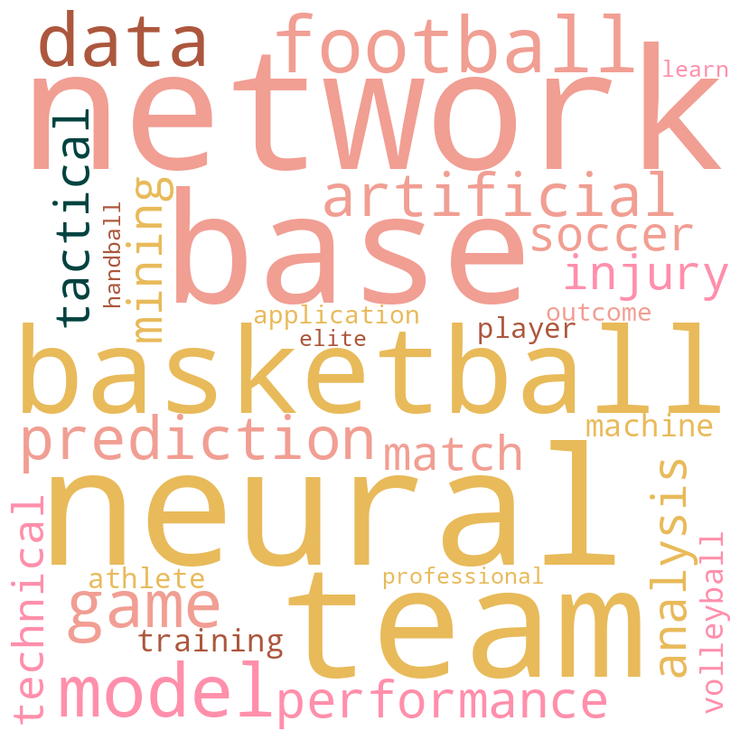

```python
import os
from wordcloud import WordCloud
import matplotlib.pyplot as plt
import random

#Provided list of words with frequencies after lemmatization (from topic_modeling.ipynb)
word_freqs_T = dict((x, y) for x, y in words_lemm_T)

#Custom color function for varying shades of pink
def pink_color_func(word, font_size, position, orientation, **kwargs):
    colors = ['#AC573D', '#F19E93', '#E8BA5A', '#FF8FAB', '#00433F']
    return random.choice(colors)

def custom_wordcloud():
    return WordCloud(width=800, height=800, background_color='white',
                     color_func=pink_color_func, random_state=123)

#Create a word cloud with varying shades of pink
wordcloud_T = custom_wordcloud().generate_from_frequencies(word_freqs_T)

# Export the image
wordcloud_T.to_file(os.path.join('..','figures','wordcloud_T.png'))

#Display the word cloud using matplotlib
plt.figure(figsize=(8, 8), facecolor=None)
plt.imshow(wordcloud_T, interpolation="bilinear")
plt.axis("off")
plt.tight_layout(pad=0)
plt.show()
```

### Word Cloud for Abstract

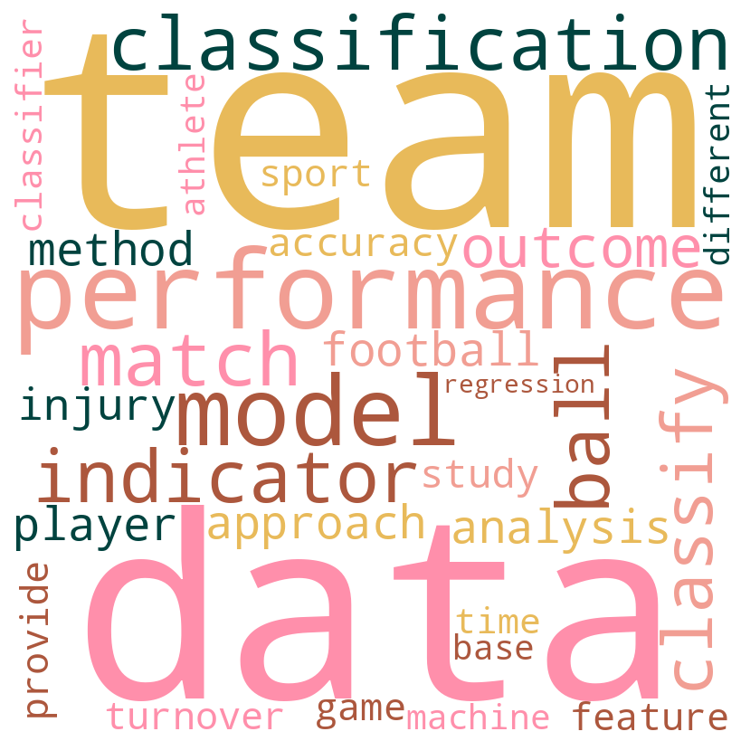

```python
word_freqs_A = dict((x, y) for x, y in words_lemm_A)

wordcloud_A = custom_wordcloud().generate_from_frequencies(word_freqs_A)

wordcloud_A.to_file(os.path.join('..','figures','wordcloud_A.png'))

#Display the word cloud using matplotlib
plt.figure(figsize=(8, 8), facecolor=None)
plt.imshow(wordcloud_A, interpolation="bilinear")
plt.axis("off")
plt.tight_layout(pad=0)
plt.show()
```

### Word Cloud for Title and Abstract

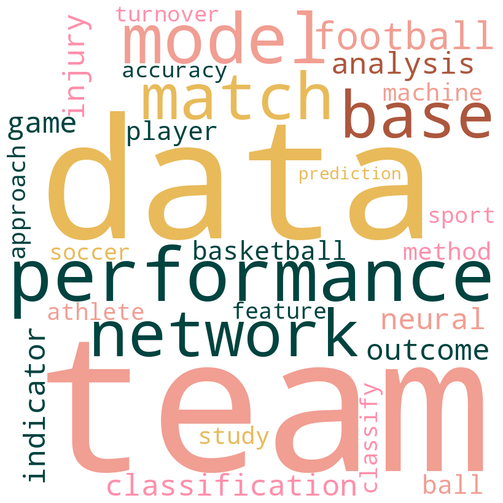

```python
word_freqs_TA = dict((x, y) for x, y in words_lemm_TA)

wordcloud_TA = custom_wordcloud().generate_from_frequencies(word_freqs_TA)

wordcloud_TA.to_file(os.path.join('..','figures','wordcloud_TA.png'))

#Display the word cloud using matplotlib
plt.figure(figsize=(8, 8), facecolor=None)
plt.imshow(wordcloud_TA, interpolation="bilinear")
plt.axis("off")
plt.tight_layout(pad=0)
plt.show()
```

### Word Cloud for Phrases

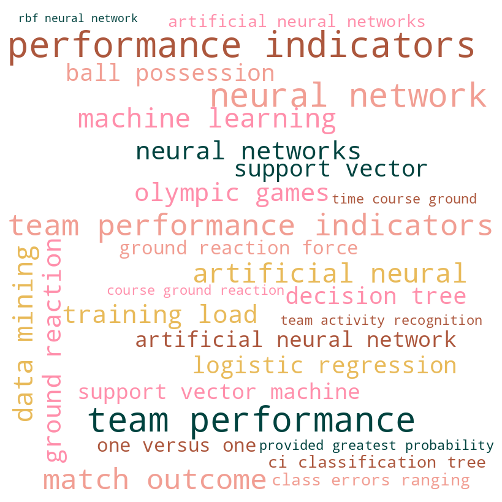

```python
phrases_freq_TA = dict((' '.join(x), y) for x, y in TA_bigrams + TA_trigrams)
phrases_freq_TA = {x: value for x, value in phrases_freq_TA.items()
                   if all(char.isalpha() or char.isspace() for char in x)}

wordcloud_phrases = custom_wordcloud().generate_from_frequencies(phrases_freq_TA)

wordcloud_phrases.to_file(os.path.join('..','figures','wordcloud_phrases.png'))

plt.figure(figsize=(8, 8), facecolor=None)
plt.imshow(wordcloud_phrases, interpolation="bilinear")
plt.axis("off")
plt.tight_layout(pad=0)
plt.show()
```

## Scrape Pubmed's database for papers by using the most common keywords found by topic modeling analysis

### Defining keywords

```python
import pandas as pd
import os

# Loading the CSV file with common strings
strings = pd.read_csv(os.path.join('..','results','common_strings.csv')).drop('Frequency', axis=1)

# Add the list of sports included in the paper
sports = ["basketball", "soccer", "volleyball", "baseball", "handball", "australian football",
          "american football", "cricket", "hockey", "rugby", "beach volley"]

# Add the list of AI techniques included in the paper
ai_techniques = ["lasso", "bayesian logistic", "bayesian network",
                 "decision tree", "fuzzy clustering", "k-means",
                 "k-nearest", "markov process", "support vector machine"]

keywords_df = pd.concat([strings,
                         pd.DataFrame(sports+ai_techniques,
                                      columns=['String'])],
                                      ignore_index=True).drop_duplicates()

keywords_df
```

|  | String |
| --- | --- |
| 0 | team |
| 1 | data |
| 2 | performance |
| 3 | model |
| 4 | base |
| ... | ... |
| 92 | bayesian network |
| 94 | fuzzy clustering |
| 95 | k-means |
| 96 | k-nearest |
| 97 | markov process |

94 rows × 1 columns

#### Subset our dataset by only retaining keywords of interest

```python
# Subset dataset by only retaining keywords with more than 4 letters
keywords_df = keywords_df[keywords_df['String'].apply(lambda x: len(x) > 4)]

# Remove some keywords we deem too generic manually
strings_to_remove = ["model", "analysis", "train", "study", "professional", "player",
                     "method", "accuracy", "outcome", "classify", "classifier",
                     "approach", "decision", "provide", "position", "different", "network",
                     "machine", "learning", "feature", "neural", "factor",
                     "one versus", "versus one", "time course", "indicator"]

# Further subseting the DataFrame by removing specified entries
keywords_df = keywords_df[~keywords_df['String'].isin(strings_to_remove)]
keywords_df.head()
```

|  | String |
| --- | --- |
| 2 | performance |
| 6 | match |
| 7 | football |
| 8 | classification |
| 10 | injury |

#### Manually add a column that categorizes each keyword (ML/statistics related, sports related, injury or performance related)

```python
# Keywords for categorization
ml_statistics_keywords = ["classification", "regression", "decision tree",
                          "vector", "neural network", "machine", "data mining",
                          "artificial neural", "non linear", "deep learning",
                          "prediction", "logistic", "indicator", "bayesian",
                          "clustering", "k-", "markov", "lasso"]
sports_keywords = ["athlete", "ball", "one versus one", "olympic",
                   "sport", "soccer", "team", "match", "turnover",
                   "volley", "cricket", "hockey", "rugby"]
injury_performance_keywords = ["injury", "performance", "training", "reaction",
                               "risk factors", "activity recognition", "impact detection"]

# Function to categorize strings
def categorize_string(s):
    if any(keyword in s for keyword in ml_statistics_keywords):
        return "ML/Statistics"
    elif any(keyword in s for keyword in sports_keywords):
        return "Sports"
    elif any(keyword in s for keyword in injury_performance_keywords):
        return "Injury/Performance"
    else:
        return "Other"

# Apply the function to create a new column
keywords_df['Category'] = keywords_df['String'].apply(categorize_string)
keywords_df.head()
```

|  | String | Category |
| --- | --- | --- |
| 2 | performance | Injury/Performance |
| 6 | match | Sports |
| 7 | football | Sports |
| 8 | classification | ML/Statistics |
| 10 | injury | Injury/Performance |

### Performing the search

```python
# Grouping the strings by category and constructing the search query for title and abstract only
# Search is performed verbatim
search_query = ' AND '.join(keywords_df.groupby
                            ('Category')['String'].apply
                            (lambda x: '("' +
                             '"[Title/Abstract] OR "'.join(x) + '"[Title/Abstract])'))
search_query
```

```
'("performance"[Title/Abstract] OR "injury"[Title/Abstract] OR "training"[Title/Abstract] OR "ground reaction"[Title/Abstract] OR "training load"[Title/Abstract] OR "activity recognition"[Title/Abstract] OR "reaction force"[Title/Abstract] OR "risk factors"[Title/Abstract] OR "impact detection"[Titl…
```

#### Search on Pubmed and show returned papers

```python
from Bio import Entrez

def fetch_from_pubmed(query, email):
    # The Pubmed API requires an email to be used
    Entrez.email = email
    # Set how the search should be performed
    handle = Entrez.esearch(db='pubmed',sort='relevance', term=query,
    # Set how many results to return
    # (we do not expect more than 10000 or so based on the paper results)
    retmax='10000', retmode='xml',
    # Just like the paper, only search up to May 2018
    mindate='1900/01', maxdate='2018/05')
    results = Entrez.read(Entrez.efetch(db='pubmed', retmode='xml',
                                        id=Entrez.read(handle)['IdList']))
    return results

mazza = 'matteo.mazzarelli@gmail.com'

paper_ids = fetch_from_pubmed(search_query, mazza)

author_list = []
title_list = []

for i, paper in enumerate(paper_ids['PubmedArticle']):
    authors = paper['MedlineCitation']['Article']['AuthorList']
    author_names = []
    for author in authors:
        # Some authors might not have a LastName or Initial, handle these cases
        last_name = author.get('LastName', '')
        initials = author.get('Initials', '')
        author_names.append(f"{last_name} {initials}".strip())

    # Join all authors' names with commas
    all_authors = ', '.join(author_names)
    author_list.append(all_authors)

    title_list.append(paper['MedlineCitation']['Article']['ArticleTitle'])

# Create a pandas df with the results
searched_papers = pd.DataFrame(list(zip(author_list, title_list)),
                               columns=['Author', 'Title'])

searched_papers.head()
```

|  | Author | Title |
| --- | --- | --- |
| 0 | Hägglund M, Waldén M | Risk factors for acute knee injury in female y... |
| 1 | Borms D, Cools A | Upper-Extremity Functional Performance Tests: ... |
| 2 | Hewett TE, Myer GD, Ford KR, Heidt RS, Colosim... | Biomechanical measures of neuromuscular contro... |
| 3 | Fullagar HHK, McCunn R, Murray A | Updated Review of the Applied Physiology of Am... |
| 4 | Moran RW, Schneiders AG, Mason J, Sullivan SJ | Do Functional Movement Screen (FMS) composite ... |

#### Compare papers found with papers in the references list

```python
# Loading the CSV file containing authors and titles of the 58 papers used in the systematic review
sys_references = pd.read_csv(os.path.join('..','results','paper_refs.csv'))

# Remove special characters from titles in order to account for inconsistencies
searched_papers['Title'] = searched_papers['Title'].str.replace(r"[^A-Za-z0-9 ]", "", regex=True)
sys_references['Title'] = sys_references['Title'].str.replace(r"[^A-Za-z0-9 ]", "", regex=True)

# Check how many papers intersect between the 2 datasets (perform inner join)
common_papers = pd.merge(sys_references, searched_papers, how='inner')
common_papers
```

|  | Author | Title |
| --- | --- | --- |
| 0 | Rein R, Memmert D | Big data and tactical analysis in elite soccer... |
| 1 | Novatchkov H, Baca A | Artificial intelligence in sports on the examp... |
| 2 | Kempe M, Grunz A, Memmert D | Detecting tactical patterns in basketball comp... |
| 3 | Link D, Hoernig M | Individual ball possession in soccer |
| 4 | Robertson S, Back N, Bartlett JD | Explaining match outcome in elite Australian R... |
| 5 | Ertelt T, Solomonovs I, Gronwald T | Enhancement of force patterns classification b... |

## Look for keywords in the metadata of the referenced papers in order to add 4 new variables to the references dataset

### Import the dataset in its post-Pubmed scraping state

```python
import pandas as pd
import os

# Loading the CSV file with references
new_variables = pd.read_csv(os.path.join('..','results','refs_abstracts_sys.csv'))
new_variables.head()
```

|  | Author | Title | Abstract | Journal | Year |
| --- | --- | --- | --- | --- | --- |
| 0 | López-Valenciano A, Ayala F, Puerta JM, et al | A preventive model for muscle injuries: a nove... | The application of contemporary statistical ap... | Medicine and science in sports and exercise | 2018.0 |
| 1 | Li C | Predict the neural network mathematical model ... | Deep learning has achieved impressive predicti... | Physical review letters | 2020.0 |
| 2 | Lu G | Evaluation model of young basketball players ’... | NaN | NaN | NaN |
| 3 | Wu L | The participating team ’s technical analysis o... | NaN | NaN | NaN |
| 4 | Zhang Q | Prediction based on basketball competition vid... | NaN | NaN | NaN |

### Manually define dictionaries of AI techniques, sports, and keywords related to injuries and sports performance, according to the information given in the paper, as well as the keywords we have extracted through topic modeling

```python
# Define dictionary of AI techniques based on Table 2
# and their most plausible corresponding aliases
ai_techniques = {
    "Absolute Shrinkage and Selection Operator": ["LASSO",
                                                  "Least Absolute Shrinkage and Selection Operator",
                                                  "L1 Regularization"],
    "Artificial Neural Network": ["ANN", "Neural Net", "Deep Learning", "Perceptron",
                                  "Self-organising map", "Self-organizing map", "SOM"],
    "Bayesian Logistic": ["Bayesian Regression", "Bayesian Model"],
    "Bayesian Network": ["Bayesian Belief", "Belief Net", "Bayes Net",
                          "Probabilistic Directed Acyclic Graphical Model"],
    "Decision Tree Classifier": ["Decision Tree", "Classification Tree", "Tree Classifier",
                                 "Classification And Regression Tree", "CART"],
    "Fuzzy Clustering": ["Fuzzy C-means", "Soft Clustering",
                         "Fuzzy K-means", "C-Means Clustering"],
    "K-means Clustering": ["K-means", "Lloyd's Algorithm",
                           "Hard Clustering", "Centroid-based Clustering"],
    "K-nearest Neighbor": ["KNN", "K-nearest",
                           "Instance-based Learning", "Lazy Learning"],
    "Markov Process": ["Markov Chain", "Markov Model"],
    "Support Vector Machine": ["SVM", "Support Vector Classifier",
                               "Support Vector Networks", "Kernel Methods"]
}

# Define dictionary of sports used in the research along with their aliases
sports = {
    "Basketball": ["Basket"],
    "Soccer": ["Association Football"],
    "Volleyball": ["Volley"],
    "Baseball": ["MLB"],
    "Handball": [],
    "Australian Football": ["AFL Football"],
    "Ice Hockey": ["Hockey", "NHL", "Stanley Cup"],
    "American Football": ["NFL Football", "College Football"],
    "Cricket": ["IPL Bowl"],
    "Field Hockey": [],
    "Rugby": []
}

# Define stemmatized keywords to help us decide
# which papers are related to injuries and/or to sporting performance
injury_keywords = ["injur", "medic", "risk", "prevent", "diagnosis", "detection"]
perf_keywords = ["performance", "techni", "tactical", "match", "position",
                 "possession", "ranking", "team", "skill", "game", "win"]
```

### Search for the keywords we have defined inside of the dataset, and add the 4 new variables (AI Technique, Sport, AI for Injury Risk, AI for Sporting Performance)

```python
# Define a function that will find instances of
# a certain item from a dictionary in text (non-exact matches allowed)
def find_dictionary(text, dictionary):
    found = []
    for item, aliases in dictionary.items():
        if item.lower() in text.lower() or any(alias.lower() in text.lower() for alias in aliases):
            found.append(item)
    return found

# Function to identify if AI is used for sporting performance prediction or injury risk
def ai_logical(text, keywords):
    for key in keywords:
        if key in text.lower():
            return "Yes"
    return "No"

# Process the dataset
ai_techniques_col = []
sports_col = []
ai_for_injury_risk_col = []
ai_for_performance_col = []

for index, paper in new_variables.iterrows():
    text = str(paper['Title']) + ' ' + str(paper['Abstract']) + ' ' + str(paper['Journal'])

    # Find AI techniques and sports
    ai_techniques_list = find_dictionary(text, ai_techniques)
    sports_list = find_dictionary(text, sports)

    # Convert to string, or use None if the list is empty
    ai_techniques_col.append(' + '.join(ai_techniques_list) if ai_techniques_list else pd.NA)
    sports_col.append(', '.join(sports_list) if sports_list else pd.NA)
    ai_for_injury_risk_col.append(ai_logical(text, injury_keywords))
    ai_for_performance_col.append(ai_logical(text, perf_keywords))

# Adding new columns to the dataset
new_variables['AI Techniques'] = ai_techniques_col
new_variables['Sports'] = sports_col
new_variables['AI for Injury Risk'] = ai_for_injury_risk_col
new_variables['AI for Performance'] = ai_for_performance_col

# Exporting the updated dataset to csv
new_variables.to_csv(os.path.join('..','results','new_variables.csv'), index=False)

new_variables.head()
```

|  | Author | Title | Abstract | Journal | Year | AI Techniques | Sports | AI for Injury Risk | AI for Performance |
| --- | --- | --- | --- | --- | --- | --- | --- | --- | --- |
| 0 | López-Valenciano A, Ayala F, Puerta JM, et al | A preventive model for muscle injuries: a nove... | The application of contemporary statistical ap... | Medicine and science in sports and exercise | 2018.0 | <NA> | <NA> | Yes | No |
| 1 | Li C | Predict the neural network mathematical model ... | Deep learning has achieved impressive predicti... | Physical review letters | 2020.0 | Artificial Neural Network | Basketball | No | Yes |
| 2 | Lu G | Evaluation model of young basketball players ’... | NaN | NaN | NaN | Artificial Neural Network | Basketball | No | Yes |
| 3 | Wu L | The participating team ’s technical analysis o... | NaN | NaN | NaN | Artificial Neural Network | Basketball | No | Yes |
| 4 | Zhang Q | Prediction based on basketball competition vid... | NaN | NaN | NaN | Artificial Neural Network | Basketball | No | No |

### Plot the most common sports and AI techniques in the dataset and investigate what they were used for

#### Plot a breakdown of AI techniques and what sports they were used in

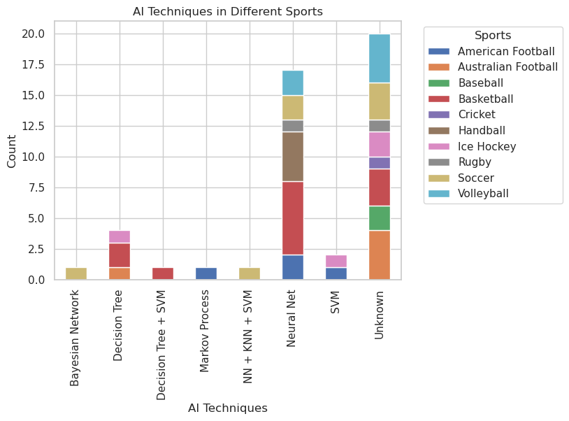

```python
import matplotlib.pyplot as plt
import seaborn as sns

# Set the plot theme
sns.set(style="whitegrid")

plots_df = new_variables.copy()

# Adding a new column to the dataset based on the specified criteria
def categorize(row):
    if row['AI for Injury Risk'] == "Yes" and row['AI for Performance'] == "Yes":
        return "Injuries & Performance"
    elif row['AI for Injury Risk'] == "Yes":
        return "Injury Risk"
    elif row['AI for Performance'] == "Yes":
        return "Performance"
    else:
        return "Unknown"

plots_df['AI Usage'] = plots_df.apply(categorize, axis=1)

# Rename AI techniques for plotting purposes
rename_dict = {
    None: 'Unknown',
    'Artificial Neural Network': 'Neural Net',
    'Bayesian Network': 'Bayesian Network',
    'Decision Tree Classifier': 'Decision Tree',
    'Artificial Neural Network + K-nearest Neighbor + Support Vector Machine': 'NN + KNN + SVM',
    'Markov Process': 'Markov Process',
    'Support Vector Machine': 'SVM',
    'Decision Tree Classifier + Support Vector Machine': 'Decision Tree + SVM'
}

plots_df['AI Techniques'] = plots_df['AI Techniques'].map(rename_dict).fillna("Unknown")

# Plot distribution of AI techniques used in different sports
ai_tech_sports = plots_df.groupby(['AI Techniques', 'Sports']).size().unstack()

# Plotting stacked bar plot for AI Techniques used for different Sports
ai_tech_sports.plot(kind='bar', stacked=True)
plt.title("AI Techniques in Different Sports")
plt.xlabel("AI Techniques")
plt.ylabel("Count")
plt.legend(title='Sports', loc='upper left', bbox_to_anchor=(1.05, 1))

plt.savefig(os.path.join('..','figures','AI_Sports.png'), bbox_inches='tight')

plt.show()
```

#### Plot whether the AI Techniques were used for performance analysis or injury risk analysis

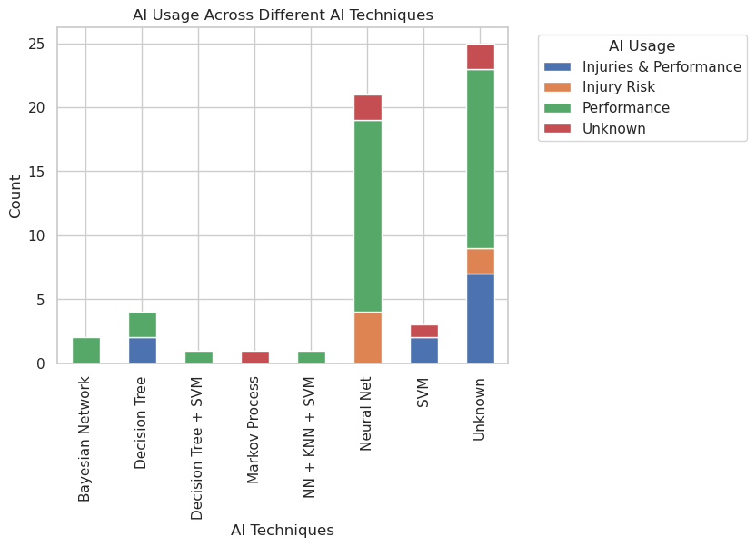

```python
# Plot distribution of AI techniques and their usage
ai_tech_usage = plots_df.groupby(['AI Techniques', 'AI Usage']).size().unstack()

# Plotting stacked bar plot for AI Usage in different AI Techniques
ai_tech_usage.plot(kind='bar', stacked=True)
plt.title("AI Usage Across Different AI Techniques")
plt.xlabel("AI Techniques")
plt.ylabel("Count")
plt.legend(title='AI Usage', bbox_to_anchor=(1.05, 1))

plt.savefig(os.path.join('..','figures','AI_Usage.png'), bbox_inches='tight')

plt.show()
```